# M0401241044_Panji Elang Permanajati_Praktikum 6 MPDW

Panji Elang Permanajati

2026-10-01

# 1 Import dan Load Data

```r
library(readxl)
library(tidyverse)
library(tseries)
library(forecast)
library(TSA)
library(lmtest)
data <- read_excel("C:\\Users\\darmo\\Downloads\\data rata rata suhu kota bogor jan 2024-sept 2026.xlsx")

head(data)
```

```
#> # A tibble: 6 × 2
#>   time                temper
#>   <dttm>               <dbl>
#> 1 2024-01-01 00:00:00   26
#> 2 2024-01-02 00:00:00   26.2
#> 3 2024-01-03 00:00:00   25.1
#> 4 2024-01-04 00:00:00   24.9
#> 5 2024-01-05 00:00:00   25.8
#> 6 2024-01-06 00:00:00   25.9
```

```r
str(data)
```

```
#> tibble [1,004 × 2] (S3: tbl_df/tbl/data.frame)
#>  $ time  : POSIXct[1:1004], format: "2024-01-01" "2024-01-02" ...
#>  $ temper: num [1:1004] 26 26.2 25.1 24.9 25.8 25.9 25.4 25.3 26.4 25.7 ...
```

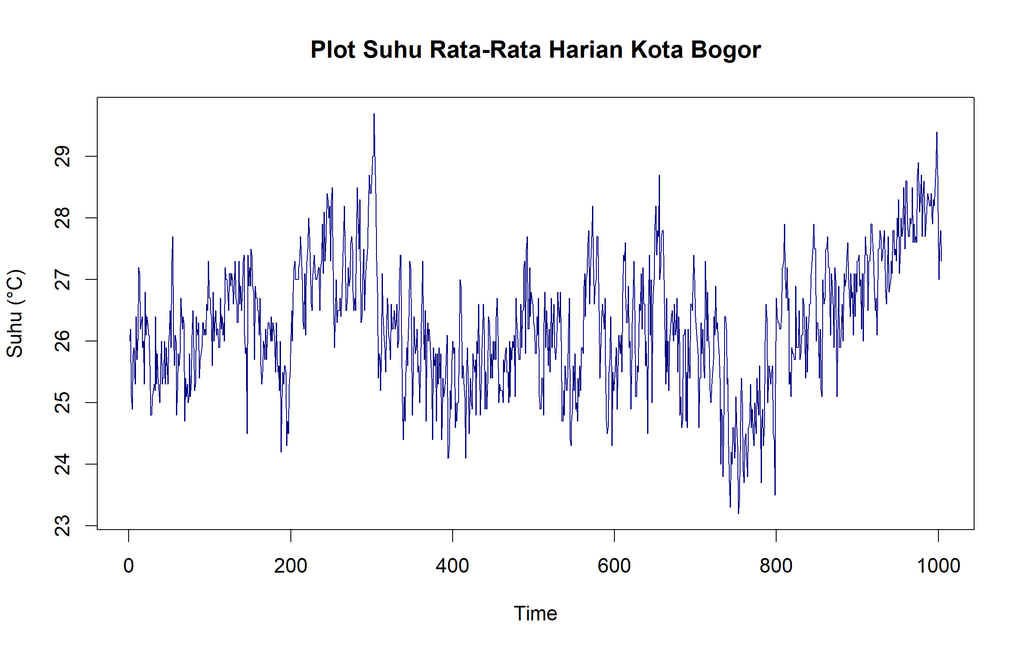

```r
suhu <- ts(data$temper)
plot.ts(suhu, main="Plot Suhu Rata-Rata Harian Kota Bogor", ylab="Suhu (°C)", col="navy")
```

Berdasarkan Plot Suhu Rata-Rata Harian Kota Bogor, terlihat bahwa suhu udara berfluktuasi pada rentang $23^\circ\text{C}$ hingga $29.5^\circ\text{C}$ secara berulang (cyclical) dan cenderung kembali ke nilai rata-ratanya di sekitar $26^\circ\text{C}$–$27^\circ\text{C}$ tanpa menunjukkan tren naik atau turun yang ekstrem, yang mengindikasikan bahwa data sudah stasioner dalam rataan, namun variasi lebar pita gelombangnya yang tidak seragam di beberapa periode menunjukkan bahwa data masih belum stasioner dalam ragam (varians).

# 2 Pembagian Data Train dan Test

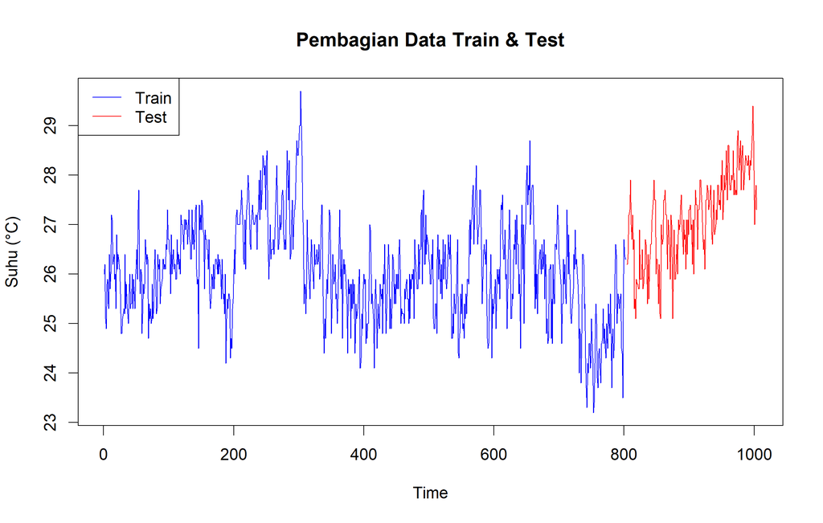

```r
n <- length(suhu)
n_train <- round(0.8 * n)

data_train <- suhu[1:n_train]
data_test  <- suhu[(n_train + 1):n]

train_ts <- ts(data_train)
test_ts  <- ts(data_test)

plot.ts(train_ts, xlim=c(1, n), ylim=range(suhu), col="blue", main="Pembagian Data Train & Test", ylab="Suhu (°C)")
lines((n_train + 1):n, test_ts, col="red")
legend("topleft", legend=c("Train", "Test"), col=c("blue", "red"), lty=1)
```

Pembagian data (data splitting) dilakukan secara kronologis untuk memisahkan 1.004 amatan menjadi dua bagian, yaitu Data Train sebesar 80% (803 amatan pertama, ditunjukkan oleh garis biru) yang digunakan untuk pembentukan dan estimasi model, serta Data Test sebesar 20% (201 amatan terakhir, ditunjukkan oleh garis merah) yang dialokasikan khusus sebagai pembanding untuk menguji tingkat akurasi hasil peramalan model ARIMA.

# 3 Cek Stasioneritas

## 3.1 Stasioner dalam Ragam (Box-Cox)

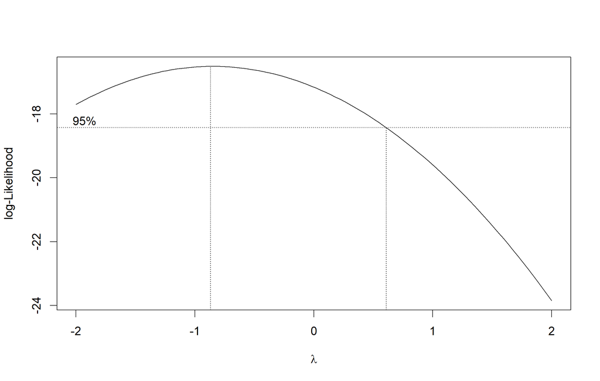

```r
library(MASS)
index <- seq_along(train_ts)
bc <- boxcox(train_ts ~ index, plotit = TRUE)
```

```r
lambda <- bc$x[which.max(bc$y)]
ci_lambda <- bc$x[bc$y > max(bc$y) - 1/2 * qchisq(0.95, 1)]

cat("Lambda Optimal :", lambda, "\n")
```

```
#> Lambda Optimal : -0.8686869
```

```r
cat("Interval CI 95% : [", min(ci_lambda), ",", max(ci_lambda), "]\n")
```

```
#> Interval CI 95% : [ -2 , 0.5858586 ]
```

Berdasarkan hasil pengujian Box-Cox, diperoleh nilai λ optimal sebesar −0.8686869 dengan interval kepercayaan 95% berada pada rentang [−2,0.5858586]. Karena interval kepercayaan tersebut tidak mengandung angka 1, maka dapat disimpulkan bahwa data suhu rata-rata harian Kota Bogor belum stasioner dalam ragam sehingga diperlukan transformasi Box-Cox pada data train sebelum melanjutkan ke tahap pemodelan ARIMA.

## 3.2 Stasioner dalam Rataan (Plot ACF dan Uji ADF)

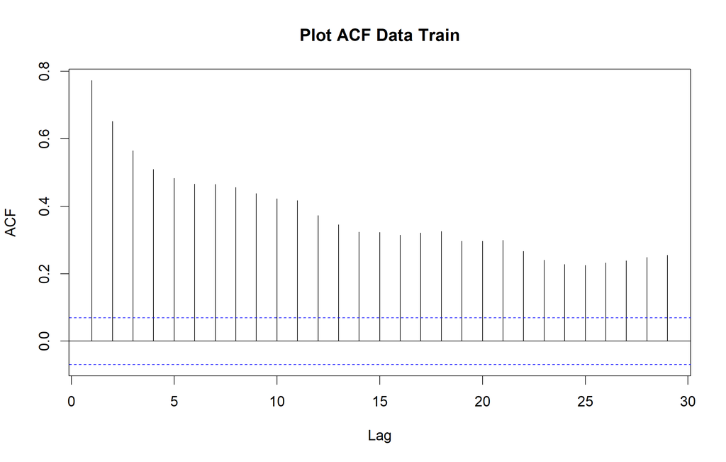

```r
acf(train_ts, main="Plot ACF Data Train")
```

```r
adf.test(train_ts)
```

[output not shown]

Berdasarkan Plot ACF, terlihat bahwa nilai autokorelasi menurun secara perlahan dari lag awal, sementara hasil uji Augmented Dickey-Fuller (ADF) menghasilkan nilai statistik $-4.5031$ dengan $p\text{-value} = 0.01$ ($< 0.05$), sehingga $\text{H}_0$ ditolak dan dapat disimpulkan bahwa data train suhu rata-rata harian Kota Bogor sudah stasioner dalam rataan pada tingkat level ($d = 0$) tanpa memerlukan proses diferencing.

## 3.3 Penanganan Ketidakstasioneran

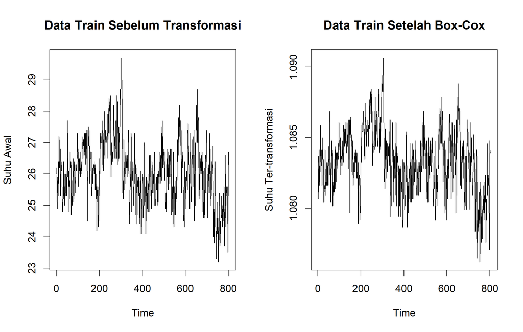

```r
if (abs(lambda) < 1e-6) {
  train_bc <- log(train_ts)
} else {
  train_bc <- (train_ts^lambda - 1) / lambda
}

par(mfrow=c(1,2))
plot.ts(train_ts, main="Data Train Sebelum Transformasi", ylab="Suhu Awal")
plot.ts(train_bc, main="Data Train Setelah Box-Cox", ylab="Suhu Ter-transformasi")
```

```r
par(mfrow=c(1,1))
```

## 3.4 Uji ADF pada Data Hasil Transformasi

```r
adf.test(train_bc)
```

[output not shown]

Berdasarkan plot perbandingan Data Train Sebelum Transformasi dan Data Train Setelah Box-Cox, terlihat bahwa penerapan transformasi Box-Cox dengan nilai $\lambda = -0.8686869$ berhasil menyeimbangkan serta meratakan lebar pita fluktuasi (varians) data suhu rata-rata harian Kota Bogor tanpa mengubah pola dasar pergerakan suhunya, sehingga data train_bc yang dihasilkan kini telah memenuhi asumsi stasioner dalam ragam dan siap digunakan untuk tahapan identifikasi serta estimasi model ARIMA($p, 0, q$).

# 4 Identifikasi Model Potensial

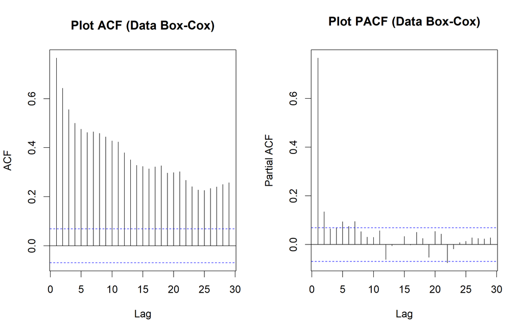

```r
par(mfrow=c(1,2))
acf(train_bc, main="Plot ACF (Data Box-Cox)")
pacf(train_bc, main="Plot PACF (Data Box-Cox)")
```

```r
par(mfrow=c(1,1))

eacf(train_bc)
```

```
#> AR/MA
#>   0 1 2 3 4 5 6 7 8 9 10 11 12 13
#> 0 x x x x x x x x x x x  x  x  x
#> 1 x o o o o o o o o o x  o  o  o
#> 2 x o o o o o o o o o x  o  o  o
#> 3 x o o o o o o o o o x  o  o  o
#> 4 x x x o o o o o o o x  o  o  o
#> 5 x x x o o o o o o o x  o  o  o
#> 6 x x x x x o o o o o o  o  o  o
#> 7 x o x x x o o o o o o  o  o  o
```

# 5 Estimasi Parameter, Signifikansi, dan Nilai AIC

```r
# Model Kandidat 1: ARIMA(1,0,1)
model1 <- Arima(train_bc, order=c(1,0,1))
summary(model1)
```

```
#> Series: train_bc
#> ARIMA(1,0,1) with non-zero mean
#>
#> Coefficients:
#>          ar1      ma1    mean
#>       0.8512  -0.2167  1.0833
#> s.e.  0.0251   0.0511  0.0003
#>
#> sigma^2 = 1.96e-06:  log likelihood = 4138.43
#> AIC=-8268.85   AICc=-8268.8   BIC=-8250.1
#>
#> Training set error measures:
#>                        ME        RMSE         MAE           MPE      MAPE      MASE
#> Training set 6.258555e-07 0.001397285 0.001088553 -0.0001090654 0.1005071 0.9380341
#>                   ACF1
#> Training set 0.0145109
```

```r
coeftest(model1)
```

```
#>
#> z test of coefficients:
#>
#>              Estimate  Std. Error   z value  Pr(>|z|)
#> ar1        0.85119960  0.02513655   33.8630 < 2.2e-16 ***
#> ma1       -0.21669625  0.05107575   -4.2426 2.209e-05 ***
#> intercept  1.08331401  0.00026023 4162.8900 < 2.2e-16 ***
#> ---
#> Signif. codes:  0 '***' 0.001 '**' 0.01 '*' 0.05 '.' 0.1 ' ' 1
```

```r
# Model Kandidat 2: ARIMA(2,0,1)
model2 <- Arima(train_bc, order=c(2,0,1))
summary(model2)
```

```
#> Series: train_bc
#> ARIMA(2,0,1) with non-zero mean
#>
#> Coefficients:
#>          ar1      ar2      ma1    mean
#>       1.4936  -0.5074  -0.8646  1.0833
#> s.e.  0.0613   0.0559   0.0440  0.0005
#>
#> sigma^2 = 1.906e-06:  log likelihood = 4150.08
#> AIC=-8290.16   AICc=-8290.09   BIC=-8266.72
#>
#> Training set error measures:
#>                         ME        RMSE         MAE           MPE       MAPE      MASE
#> Training set -2.017801e-06 0.001376997 0.001076236 -0.0003484421 0.09936912 0.9274206
#>                      ACF1
#> Training set -0.008064007
```

```r
coeftest(model2)
```

```
#>
#> z test of coefficients:
#>
#>              Estimate  Std. Error   z value  Pr(>|z|)
#> ar1        1.49355491  0.06127674   24.3739 < 2.2e-16 ***
#> ar2       -0.50743561  0.05588694   -9.0797 < 2.2e-16 ***
#> ma1       -0.86460104  0.04397632  -19.6606 < 2.2e-16 ***
#> intercept  1.08331436  0.00045985 2355.7994 < 2.2e-16 ***
#> ---
#> Signif. codes:  0 '***' 0.001 '**' 0.01 '*' 0.05 '.' 0.1 ' ' 1
```

```r
# Model Kandidat 3: ARIMA(1,0,2)
model3 <- Arima(train_bc, order=c(1,0,2))
summary(model3)
```

```
#> Series: train_bc
#> ARIMA(1,0,2) with non-zero mean
#>
#> Coefficients:
#>          ar1      ma1      ma2    mean
#>       0.9191  -0.3028  -0.1535  1.0833
#> s.e.  0.0255   0.0502   0.0512  0.0003
#>
#> sigma^2 = 1.943e-06:  log likelihood = 4142.4
#> AIC=-8274.79   AICc=-8274.72   BIC=-8251.35
#>
#> Training set error measures:
#>                        ME        RMSE         MAE           MPE     MAPE      MASE
#> Training set 6.260227e-07 0.001390334 0.001086253 -0.0001078355 0.100295 0.9360527
#>                    ACF1
#> Training set 0.01718717
```

```r
coeftest(model3)
```

```
#>
#> z test of coefficients:
#>
#>             Estimate Std. Error   z value  Pr(>|z|)
#> ar1        0.9190855  0.0255412   35.9845 < 2.2e-16 ***
#> ma1       -0.3027608  0.0502318   -6.0273 1.668e-09 ***
#> ma2       -0.1535051  0.0511683   -3.0000    0.0027 **
#> intercept  1.0833143  0.0003275 3307.7836 < 2.2e-16 ***
#> ---
#> Signif. codes:  0 '***' 0.001 '**' 0.01 '*' 0.05 '.' 0.1 ' ' 1
```

```r
# Perbandingan Nilai AIC
data.frame(
  Model = c("ARIMA(1,0,1)", "ARIMA(2,0,1)", "ARIMA(1,0,2)"),
  AIC   = c(model1$aic, model2$aic, model3$aic)
)
```

```
#>          Model       AIC
#> 1 ARIMA(1,0,1) -8268.853
#> 2 ARIMA(2,0,1) -8290.162
#> 3 ARIMA(1,0,2) -8274.793
```

Di antara ketiga kandidat yang parameternya sama-sama signifikan, ARIMA(2,0,1) memiliki nilai AIC paling minimum, yaitu $-8290.162$. Karena semua parameter pada ARIMA(2,0,1) signifikan dan memberikan tingkat kebaikan fit (log-likelihood) paling tinggi ($4150.08$), model ini layak dipilih sebagai model terbaik untuk digunakan pada tahap diagnostik sisaan dan peramalan.

# 6 Diagnostik Residual

```r
model_terbaik <- model2
residual <- residuals(model_terbaik)

t.test(residual)
```

```
#>
#>  One Sample t-test
#>
#> data:  residual
#> t = -0.041499, df = 802, p-value = 0.9669
#> alternative hypothesis: true mean is not equal to 0
#> 95 percent confidence interval:
#>  -9.746199e-05  9.342639e-05
#> sample estimates:
#>     mean of x
#> -2.017801e-06
```

```r
Box.test(residual, type = "Ljung-Box")
```

```
#>
#>  Box-Ljung test
#>
#> data:  residual
#> X-squared = 0.052413, df = 1, p-value = 0.8189
```

```r
jarque.bera.test(residual)
```

```
#>
#>  Jarque Bera Test
#>
#> data:  residual
#> X-squared = 19.559, df = 2, p-value = 5.659e-05
```

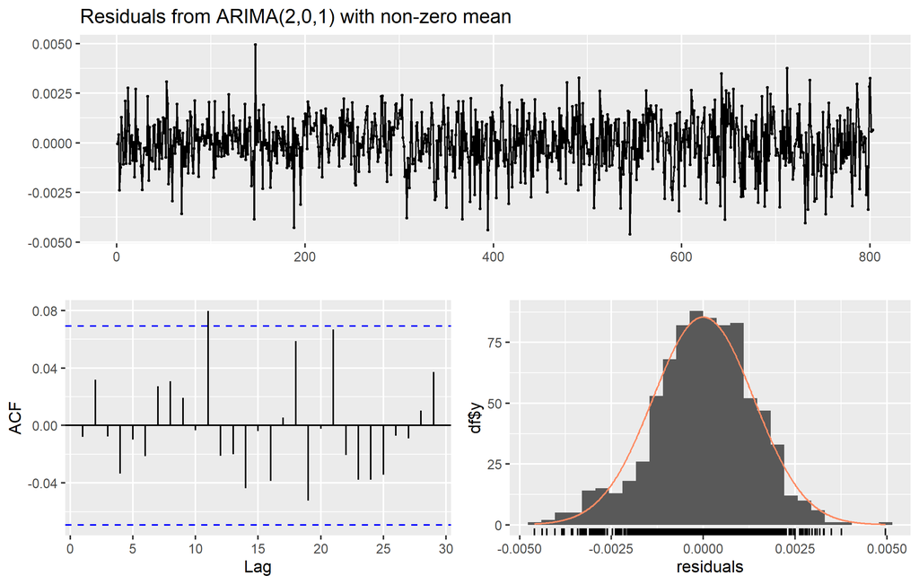

```
#>
#>  Ljung-Box test
#>
#> data:  Residuals from ARIMA(2,0,1) with non-zero mean
#> Q* = 3.954, df = 7, p-value = 0.7851
#>
#> Model df: 3.   Total lags used: 10
```

```r
checkresiduals(model_terbaik)
```

Berdasarkan pengujian diagnostik residual, uji One Sample t-test menghasilkan $p\text{-value} = 0.9669$ ($>0.05$) yang mengindikasikan bahwa rata-rata sisaan sama dengan nol dan uji Ljung-Box menghasilkan $p\text{-value} = 0.8189$ ($>0.05$) yang menunjukkan sisaan telah bersifat white noise (saling bebas/tidak ada autokorelasi), namun uji Jarque-Bera menghasilkan $p\text{-value} = 5.659 \times 10^{-5}$ ($<0.05$) yang mengindikasikan sisaan belum berdistribusi normal, sehingga secara umum model telah memenuhi asumsi dasar ekspektasi nol dan white noise meskipun terdapat sedikit deviasi pada normalitas sisaannya.

# 7 Uji Overfitting

```r
# Overfitting ke ARIMA(1,0,1)
model_overfit1 <- Arima(train_bc, order=c(1,0,1))
coeftest(model_overfit1)
```

```
#>
#> z test of coefficients:
#>
#>              Estimate  Std. Error   z value  Pr(>|z|)
#> ar1        0.85119960  0.02513655   33.8630 < 2.2e-16 ***
#> ma1       -0.21669625  0.05107575   -4.2426 2.209e-05 ***
#> intercept  1.08331401  0.00026023 4162.8900 < 2.2e-16 ***
#> ---
#> Signif. codes:  0 '***' 0.001 '**' 0.01 '*' 0.05 '.' 0.1 ' ' 1
```

```r
# Overfitting ke ARIMA(1,0,2)
model_overfit2 <- Arima(train_bc, order=c(1,0,2))
coeftest(model_overfit2)
```

```
#>
#> z test of coefficients:
#>
#>             Estimate Std. Error   z value  Pr(>|z|)
#> ar1        0.9190855  0.0255412   35.9845 < 2.2e-16 ***
#> ma1       -0.3027608  0.0502318   -6.0273 1.668e-09 ***
#> ma2       -0.1535051  0.0511683   -3.0000    0.0027 **
#> intercept  1.0833143  0.0003275 3307.7836 < 2.2e-16 ***
#> ---
#> Signif. codes:  0 '***' 0.001 '**' 0.01 '*' 0.05 '.' 0.1 ' ' 1
```

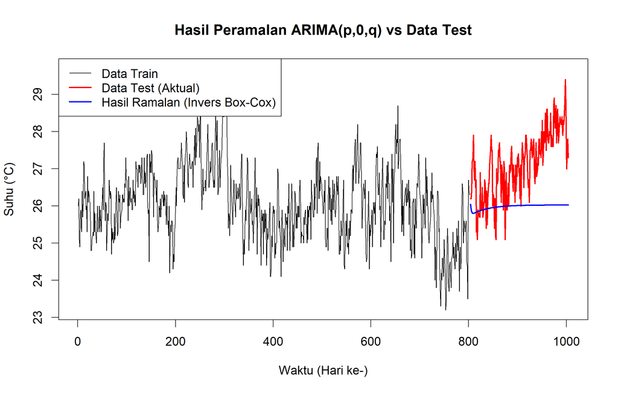

```r
h_test <- length(test_ts)

ramalan_bc <- forecast(model_terbaik, h = h_test)

if (abs(lambda) < 1e-6) {
  ramalan_skala_asli <- exp(ramalan_bc$mean)
} else {
  ramalan_skala_asli <- (ramalan_bc$mean * lambda + 1)^(1 / lambda)
}

y_min <- min(c(as.numeric(suhu), ramalan_skala_asli), na.rm = TRUE)
y_max <- max(c(as.numeric(suhu), ramalan_skala_asli), na.rm = TRUE)

plot(1:n_train, as.numeric(train_ts), type = "l", col = "black",
     xlim = c(1, n), ylim = c(y_min, y_max),
     main = "Hasil Peramalan ARIMA(p,0,q) vs Data Test",
     xlab = "Waktu (Hari ke-)", ylab = "Suhu (°C)")

lines((n_train + 1):n, as.numeric(test_ts), col = "red", lwd = 2)
lines((n_train + 1):n, ramalan_skala_asli, col = "blue", lwd = 2)

legend("topleft",
       legend = c("Data Train", "Data Test (Aktual)", "Hasil Ramalan (Invers Box-Cox)"),
       col = c("black", "red", "blue"),
       lty = 1, lwd = c(1, 2, 2))
```

```r
accuracy(ramalan_skala_asli, as.numeric(test_ts))
```

```
#>                ME    RMSE      MAE     MPE     MAPE
#> Test set 1.125882 1.40656 1.195932 4.05656 4.332977
```